# QK Box 8.13

Constable (1993) studied the role of sutures in the shrinking of the test of the sea urchin Heliocidaris erythrogramma under different food regimes. The categorical predictor (factor) was food regime with three groups: high food regime, low food regime, and an initial sample. The response variable was the width of inter-radial sutures (mm) from each urchin and initial body volume (ml) was the covariate. There were 24 urchins in each group. Constable (1993) transformed body volume to cube roots to linearise the relationship between suture width and body volume, and while a scatterplot suggested the relationships were approximately linear (Figure 8.15), we will be consistent with the original paper and also apply transformation.

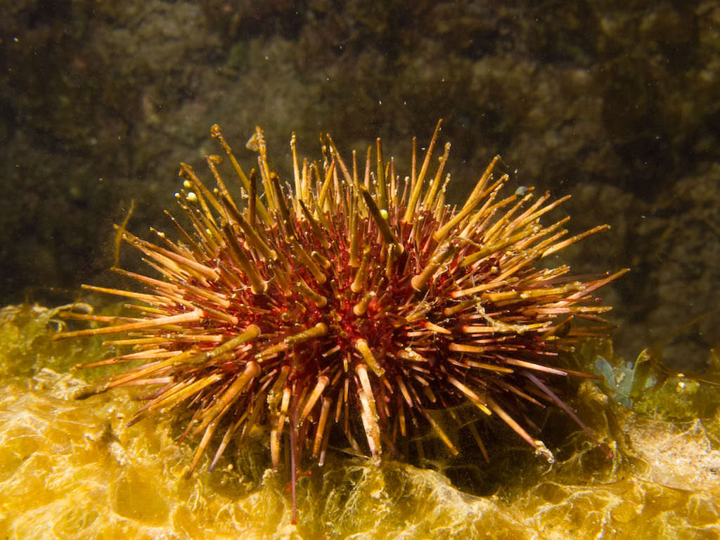

Heliocidaris erythrogramma. Mick Keough, [CC BY 4.0](https://creativecommons.org/licenses/by/4.0/).

This example was used in the first edition; the data file is here

Constable, A. J. (1993). The role of sutures in shrinking of the test in *Heliocidaris erythrogramma* (Echinoidea: Echinometridae). *Marine Biology*, 117, 423-30.

### Preliminaries

ancova for urchin data First, load the required packages (car, kader, reghelper, interactions)

Import constable data file (constable.csv)

```r
constable <- read.csv("../data/constable.csv")
head(constable,10)
```

|  | treatment | bodyvol | sutwidth |
| --- | --- | --- | --- |
| 1 | initial | 3.5 | 0.010 |
| 2 | initial | 5.0 | 0.020 |
| 3 | initial | 8.0 | 0.061 |
| 4 | initial | 10.0 | 0.051 |
| 5 | initial | 13.0 | 0.041 |
| 6 | initial | 13.0 | 0.061 |
| 7 | initial | 15.0 | 0.041 |
| 8 | initial | 15.0 | 0.071 |
| 9 | initial | 16.0 | 0.092 |
| 10 | initial | 17.0 | 0.051 |

```r
constable$treatment<-factor(constable$treatment)
```

### Check assumptions

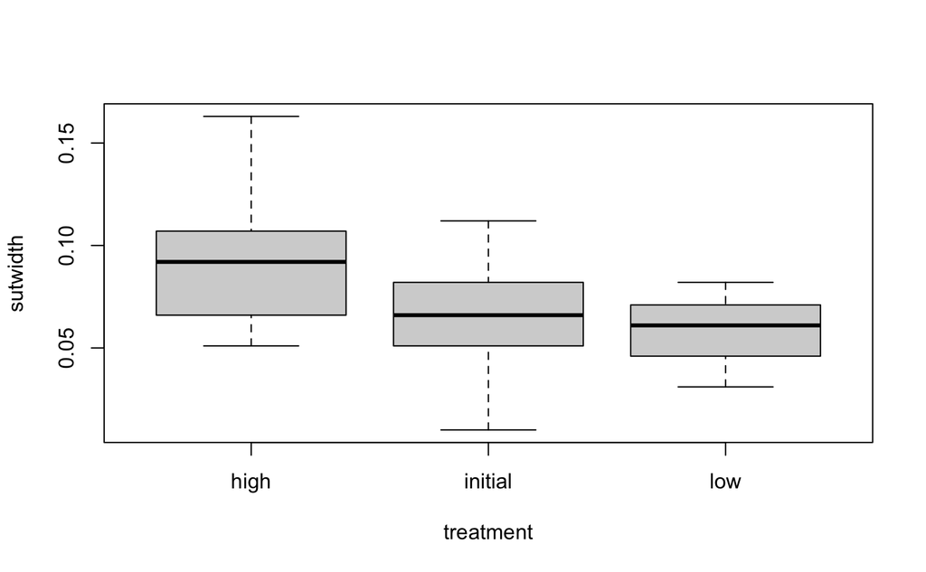

```r
boxplot(sutwidth~treatment, data=constable)
```

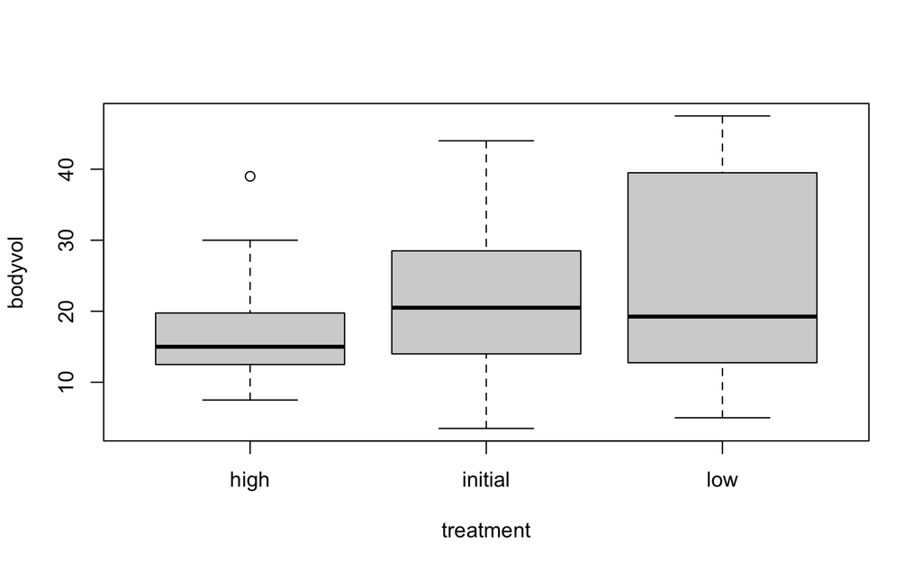

```r
boxplot(bodyvol~treatment, data=constable)
```

Boxplots don’t indicate major skewness or markedly unequal variances

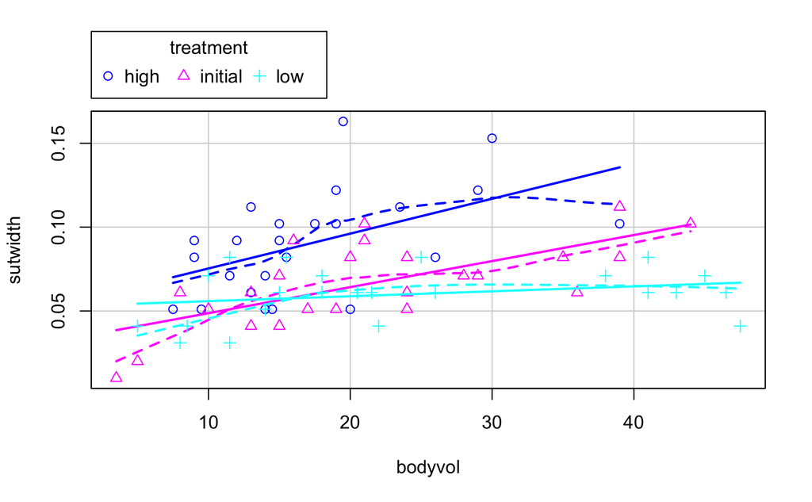

```r
scatterplot(sutwidth ~ bodyvol | treatment, data = constable)
```

Lines look reasonably linear (except maybe low) but not parallel (esp. low shallower than others) but original author transformed body volume to cube root so we will too.

```r
constable$cbodyvol <- (constable$bodyvol)^(1/3)
```

Check that covariate not affected by treatments

```r
cov.aov <- aov(cbodyvol~treatment, data=constable)
summary(cov.aov)
```

```
            Df Sum Sq Mean Sq F value Pr(>F)
treatment    2  0.656  0.3278   1.363  0.263
Residuals   69 16.591  0.2404
```

### Fit full model with interaction to evaluate homogeneous slopes

All SS types produce same result for interaction

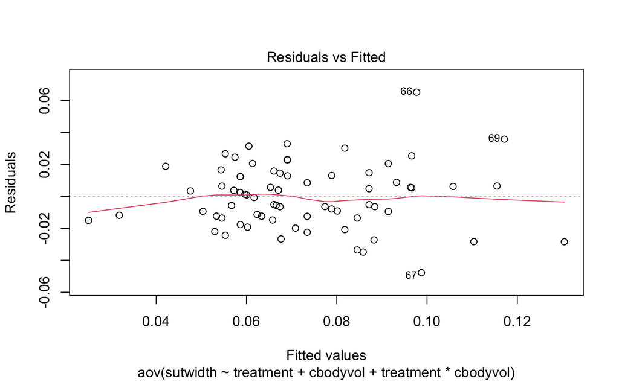

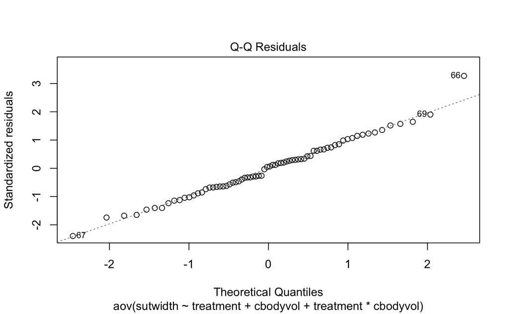

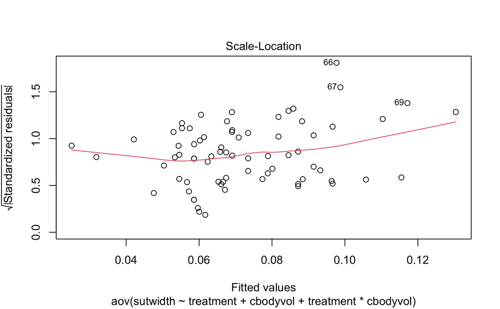

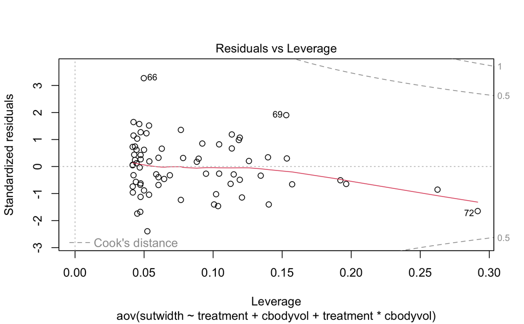

```r
constable.aov1 <- aov(sutwidth~treatment+cbodyvol+treatment*cbodyvol, data=constable)
plot(constable.aov1)
```

Residual plot looks OK

```r
summary(constable.aov1)
```

```
                   Df   Sum Sq  Mean Sq F value   Pr(>F)
treatment           2 0.012380 0.006190  14.754 5.05e-06 ***
cbodyvol            1 0.010907 0.010907  25.997 3.09e-06 ***
treatment:cbodyvol  2 0.003944 0.001972   4.701   0.0123 *
Residuals          66 0.027690 0.000420
---
Signif. codes:  0 ‘***’ 0.001 ‘**’ 0.01 ‘*’ 0.05 ‘.’ 0.1 ‘ ’ 1
```

Conclude evidence for non-parallel slopes

### Repeat analysis using lm - set low food as reference to get high vs low contrast

```r
constable$treatment <- relevel(constable$treatment, ref="low")
constable.lm1 <- lm(sutwidth~treatment+cbodyvol+treatment*cbodyvol, data=constable)
anova(constable.lm1)
```

```
Analysis of Variance Table

Response: sutwidth
                   Df    Sum Sq   Mean Sq F value    Pr(>F)
treatment           2 0.0123801 0.0061900 14.7542 5.053e-06 ***
cbodyvol            1 0.0109067 0.0109067 25.9965 3.094e-06 ***
treatment:cbodyvol  2 0.0039443 0.0019721  4.7007   0.01234 *
Residuals          66 0.0276899 0.0004195
---
Signif. codes:  0 ‘***’ 0.001 ‘**’ 0.01 ‘*’ 0.05 ‘.’ 0.1 ‘ ’ 1
```

```r
summary(constable.lm1)
```

```
Call:
lm(formula = sutwidth ~ treatment + cbodyvol + treatment * cbodyvol,
    data = constable)

Residuals:
      Min        1Q    Median        3Q       Max
-0.047764 -0.012727  0.001153  0.012959  0.065303

Coefficients:
                           Estimate Std. Error t value Pr(>|t|)
(Intercept)                0.034871   0.021224   1.643   0.1051
treatmenthigh             -0.063073   0.037350  -1.689   0.0960 .
treatmentinitial          -0.063663   0.030892  -2.061   0.0433 *
cbodyvol                   0.009053   0.007522   1.204   0.2330
treatmenthigh:cbodyvol     0.037721   0.014161   2.664   0.0097 **
treatmentinitial:cbodyvol  0.026395   0.011117   2.374   0.0205 *
---
Signif. codes:  0 ‘***’ 0.001 ‘**’ 0.01 ‘*’ 0.05 ‘.’ 0.1 ‘ ’ 1

Residual standard error: 0.02048 on 66 degrees of freedom
Multiple R-squared:  0.4958,    Adjusted R-squared:  0.4576
F-statistic: 12.98 on 5 and 66 DF,  p-value: 8.431e-09
```

A nice plot is available from the interactions package

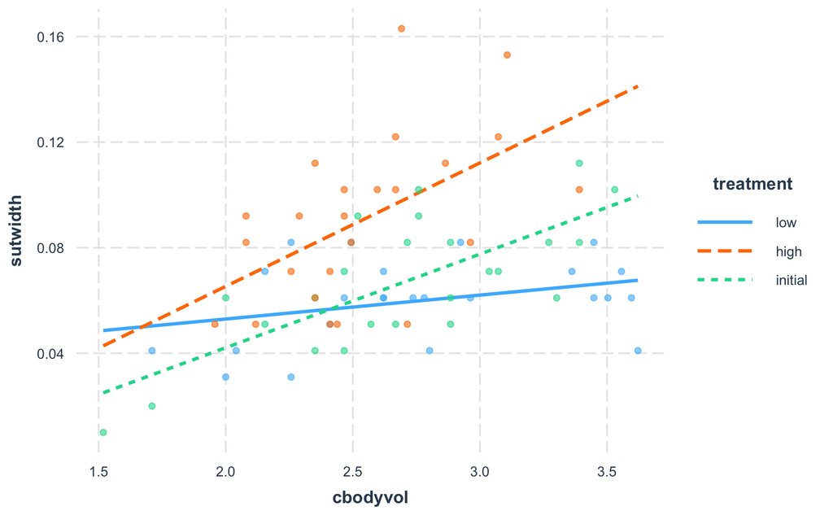

```r
interact_plot(constable.lm1, pred=cbodyvol, modx=treatment, plot.points=TRUE)
```

Simple slopes

```r
simple_slopes(constable.lm1)
```

```
         treatment cbodyvol Test Estimate Std. Error t value df  Pr(>|t|) Sig.
1              low   sstest        0.0091     0.0075  1.2037 66 0.2330190
2             high   sstest        0.0468     0.0120  3.8985 66 0.0002291  ***
3          initial   sstest        0.0354     0.0082  4.3302 66 5.177e-05  ***
4    sstest (high)  2.17322        0.0189     0.0086  2.1975 66 0.0315008    *
5 sstest (initial)  2.17322       -0.0063     0.0085 -0.7373 66 0.4635775
6    sstest (high) 2.666077        0.0375     0.0062  6.0902 66 6.464e-08  ***
7 sstest (initial) 2.666077        0.0067     0.0060  1.1244 66 0.2648959
8    sstest (high) 3.158934        0.0561     0.0100  5.6304 66 3.988e-07  ***
9 sstest (initial) 3.158934        0.0197     0.0076  2.5853 66 0.0119446    *
```

### Johnson-Neyman procedure

Available in package *interactions*

**Note for fixing; can’t get pairwise sets, so using subsets of data** **Not sure how to deal with categorical predictor, though it should be possible; manual not clear**

```r
# Look at low vs high
#create dummy variables
library(fastDummies)
df <- constable[constable$treatment %in% c('low','high'),]
df <- dummy_cols(df, select_columns = 'treatment')
constable.lm2 <- lm(sutwidth~treatment_high*cbodyvol, data = df)
anova(constable.lm2)
```

```
Analysis of Variance Table

Response: sutwidth
                        Df    Sum Sq   Mean Sq F value    Pr(>F)
treatment_high           1 0.0112241 0.0112241 23.6210 1.528e-05 ***
cbodyvol                 1 0.0040072 0.0040072  8.4332  0.005742 **
treatment_high:cbodyvol  1 0.0029769 0.0029769  6.2650  0.016101 *
Residuals               44 0.0209077 0.0004752
---
Signif. codes:  0 ‘***’ 0.001 ‘**’ 0.01 ‘*’ 0.05 ‘.’ 0.1 ‘ ’ 1
```

```
JOHNSON-NEYMAN INTERVAL

When cbodyvol is OUTSIDE the interval [-2.25, 2.17], the slope of treatment_high
is p < .05.

Note: The range of observed values of cbodyvol is [1.71, 3.62]
```

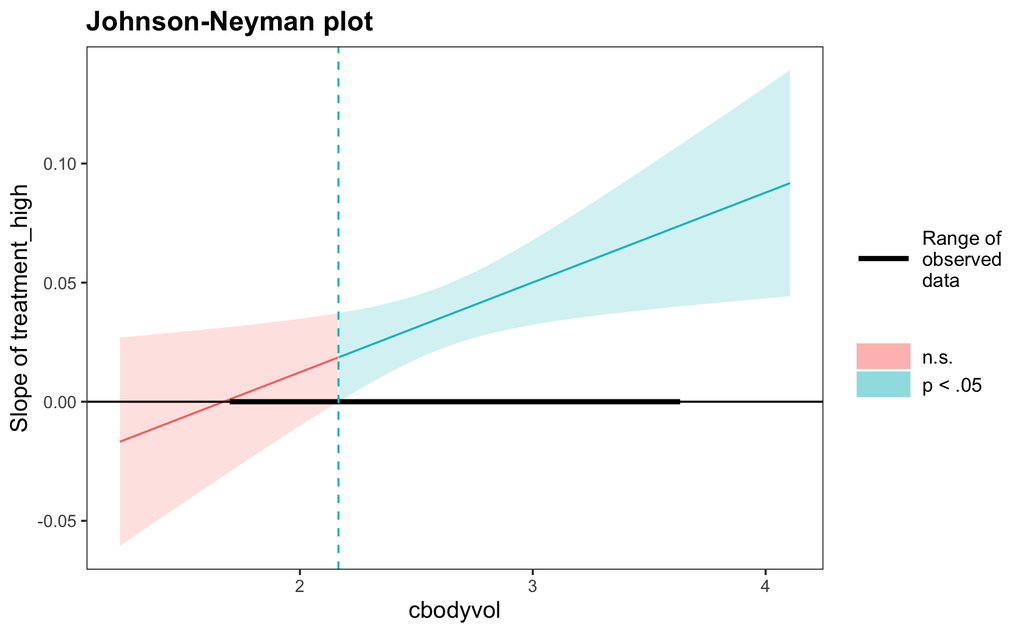

```r
johnson_neyman(model = constable.lm2, pred = treatment_high, modx = cbodyvol)
```

```
JOHNSON-NEYMAN INTERVAL

When cbodyvol is OUTSIDE the interval [1.51, 2.78], the slope of
treatment_initial is p < .05.

Note: The range of observed values of cbodyvol is [1.52, 3.62]
```

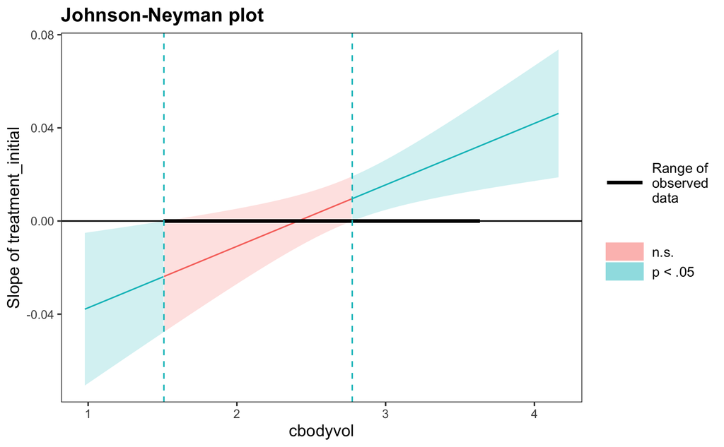

```r
# Now low vs initial
df2 <- constable[constable$treatment %in% c('low','initial'),]
#df2 <- subset(constable, treatment !='high')
df2 <- dummy_cols(df2, select_columns = 'treatment')
constable.lm3 <- lm(sutwidth~treatment_initial*cbodyvol, data = df2)
johnson_neyman(model = constable.lm3, pred = treatment_initial, modx = cbodyvol)
```

```
JOHNSON-NEYMAN INTERVAL

When cbodyvol is INSIDE the interval [2.00, 3.91], the slope of treatment_initial
is p < .05.

Note: The range of observed values of cbodyvol is [1.52, 3.53]
```

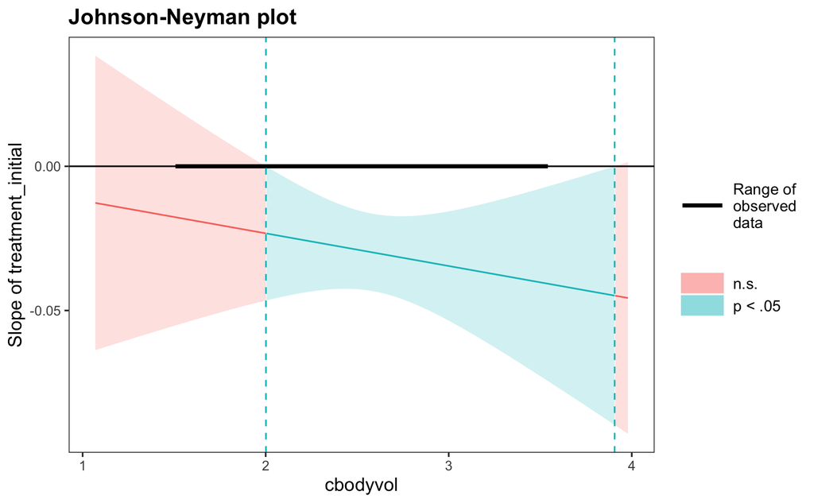

```r
# Now high vs initial
df3 <- constable[constable$treatment %in% c('initial','high'),]
df3 <- dummy_cols(df3, select_columns = 'treatment')
constable.lm4 <- lm(sutwidth~treatment_initial*cbodyvol, data = df3)
johnson_neyman(model = constable.lm4, pred = treatment_initial, modx = cbodyvol)
```

Alternative package for J-N

```
$coeff
Generalized least squares fit by REML
  Model: Yi ~ Xi * gi
  Data: NULL
```

|  | AIC | BIC | logLik |
| --- | --- | --- | --- |
|  | -192.3845 | -183.4635 | 101.1922 |

```
Coefficients:
```

|  | Value | Std.Error | t-value | p-value |
| --- | --- | --- | --- | --- |
| (Intercept) | 0.03487128 | 0.02258684 | 1.543876 | 0.1298 |
| Xi | 0.00905339 | 0.00800468 | 1.131012 | 0.2642 |
| gihigh | -0.06307300 | 0.03974895 | -1.586784 | 0.1197 |
| Xi:gihigh | 0.03772102 | 0.01507038 | 2.502990 | 0.0161 |

```
 Correlation:
          (Intr) Xi     gihigh
Xi        -0.980
gihigh    -0.568  0.557
Xi:gihigh  0.521 -0.531 -0.987

Standardized residuals:
        Min          Q1         Med          Q3         Max
-2.19114183 -0.58031084  0.08608482  0.59449162  2.99577686

Residual standard error: 0.02179849
Degrees of freedom: 48 total; 44 residual

$`lower limit in X`
(Intercept)
   1.325842

$`upper limit in X`
(Intercept)
   2.019806
```

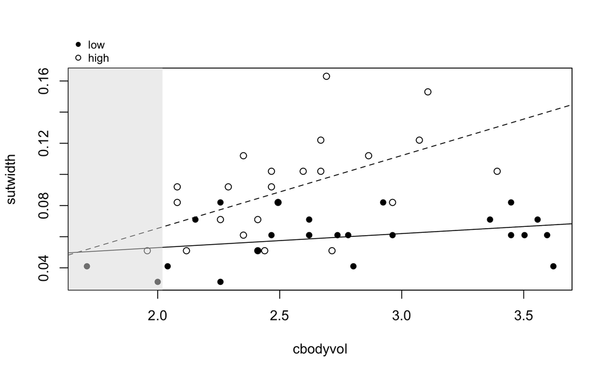

```r
devtools::install_github('kenstoyama/JNplots')
library(JNplots)
#Note that it seems to only deal with categorical predictors with 2 levels
jnt_cat(X='cbodyvol', Y='sutwidth', m='treatment', data=df)
```

```
$coeff
Generalized least squares fit by REML
  Model: Yi ~ Xi * gi
  Data: NULL
```

|  | AIC | BIC | logLik |
| --- | --- | --- | --- |
|  | -216.7506 | -207.8297 | 113.3753 |

```
Coefficients:
```

|  | Value | Std.Error | t-value | p-value |
| --- | --- | --- | --- | --- |
| (Intercept) | 0.03487128 | 0.016975844 | 2.054171 | 0.0459 |
| Xi | 0.00905339 | 0.006016168 | 1.504844 | 0.1395 |
| giinitial | -0.06366290 | 0.024709222 | -2.576483 | 0.0134 |
| Xi:giinitial | 0.02639477 | 0.008892047 | 2.968357 | 0.0048 |

```
 Correlation:
             (Intr) Xi     giintl
Xi           -0.980
giinitial    -0.687  0.674
Xi:giinitial  0.663 -0.677 -0.981

Standardized residuals:
         Min           Q1          Med           Q3          Max
-1.663619995 -0.729695423  0.008010786  0.755476536  2.013803900

Residual standard error: 0.01638333
Degrees of freedom: 48 total; 44 residual

$`lower limit in X`
(Intercept)
    2.02381

$`upper limit in X`
(Intercept)
   2.800654
```

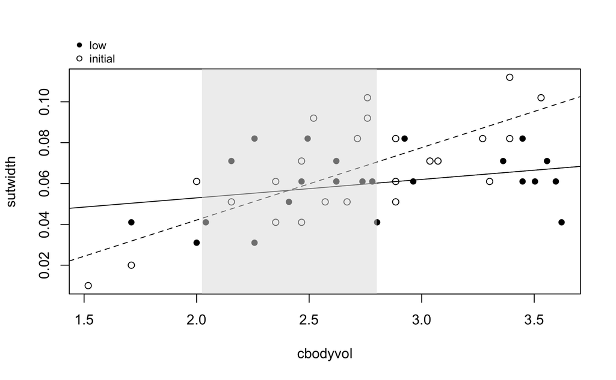

```r
jnt_cat(X='cbodyvol', Y='sutwidth', m='treatment', data=df2)
```

```
$coeff
Generalized least squares fit by REML
  Model: Yi ~ Xi * gi
  Data: NULL
```

|  | AIC | BIC | logLik |
| --- | --- | --- | --- |
|  | -189.0089 | -180.0879 | 99.50443 |

```
Coefficients:
```

|  | Value | Std.Error | t-value | p-value |
| --- | --- | --- | --- | --- |
| (Intercept) | -0.02820171 | 0.03405252 | -0.828183 | 0.4120 |
| Xi | 0.04677441 | 0.01329365 | 3.518553 | 0.0010 |
| giinitial | -0.00058990 | 0.04216804 | -0.013989 | 0.9889 |
| Xi:giinitial | -0.01132625 | 0.01609316 | -0.703793 | 0.4853 |

```
 Correlation:
             (Intr) Xi     giintl
Xi           -0.991
giinitial    -0.808  0.800
Xi:giinitial  0.818 -0.826 -0.987

Standardized residuals:
        Min          Q1         Med          Q3         Max
-2.10462809 -0.61110459 -0.03835316  0.59392696  2.87749339

Residual standard error: 0.02269455
Degrees of freedom: 48 total; 44 residual

$`lower limit in X`
(Intercept)
  -1.188155

$`upper limit in X`
(Intercept)
   1.131917
```

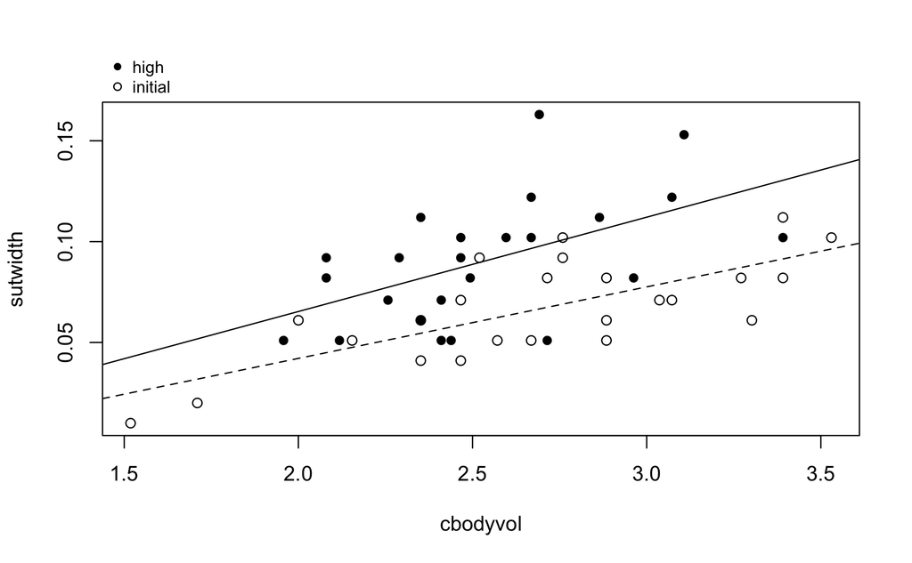

```r
jnt_cat(X='cbodyvol', Y='sutwidth', m='treatment', data=df3)
```